# Mid Exam

# ● Section 3 - T-test

## Instructions

Consider the following A/B testing data. This data tracks a user’s time on page (timeOnPage) and the UI design (design). In A/B testing, we are concerned with the difference between the two groups on the outcome. Select the appropriate technique from the general linear model and determine if any significant differences exist between the two competing page designs. Describe your rationale for any data processing that you might undertake.

Discuss your results and indicate any actionable decision that comes from your analysis. Additionally, determine if your analyses were sufficiently powered.

## Solution

```r
sec3Link <- read.csv("https://www.nd.edu/~sberry5/data/abData.csv")
summary(sec3Link)
```

```
##  PageConfiguration MinutesOnPage
##  A:505             Min.   :1.671
##  B:554             1st Qu.:2.993
##                    Median :3.869
##                    Mean   :4.433
##                    3rd Qu.:5.918
##                    Max.   :7.378
```

```r
a = lm(MinutesOnPage~PageConfiguration, data = sec3Link)
summary(a)
```

```
##
## Call:
## lm(formula = MinutesOnPage ~ PageConfiguration, data = sec3Link)
##
## Residuals:
##     Min      1Q  Median      3Q     Max
## -1.4180 -0.3348 -0.0122  0.3544  1.5218
##
## Coefficients:
##                    Estimate Std. Error t value Pr(>|t|)
## (Intercept)         5.97486    0.02256  264.82   <2e-16 ***
## PageConfigurationB -2.94721    0.03119  -94.48   <2e-16 ***
## ---
## Signif. codes:  0 '***' 0.001 '**' 0.01 '*' 0.05 '.' 0.1 ' ' 1
##
## Residual standard error: 0.507 on 1057 degrees of freedom
## Multiple R-squared:  0.8941, Adjusted R-squared:  0.894
## F-statistic:  8927 on 1 and 1057 DF,  p-value: < 2.2e-16
```

For define the signigicant differences between two groups, t-test will be the best way. I can make a H0 first, group A and group B have the same mean.

But before doing a t-test, I want to draw a boxplot to do some data exploration.

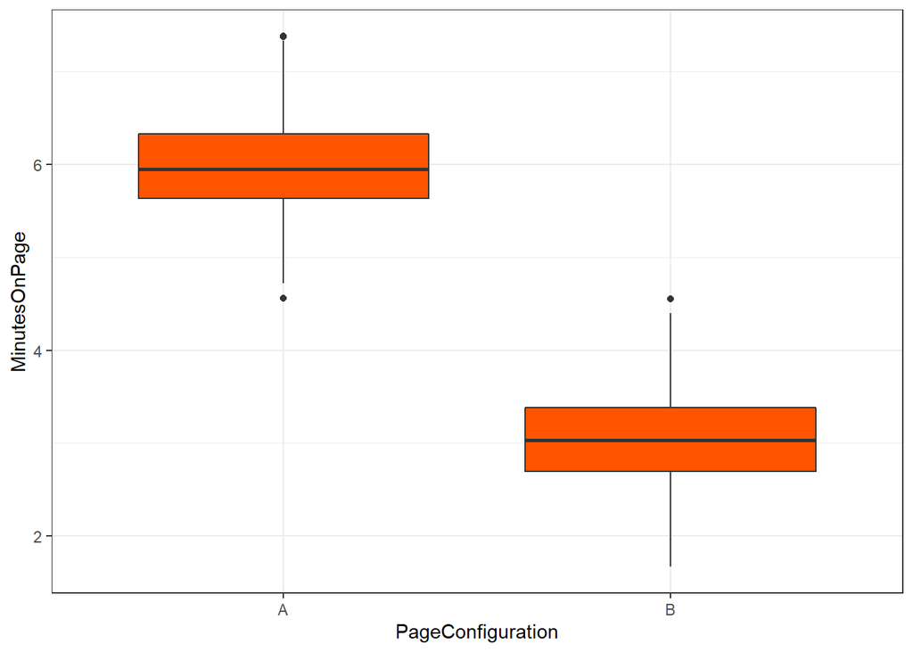

```r
ggplot(sec3Link, aes(PageConfiguration, MinutesOnPage)) +
  geom_boxplot(fill = "#ff5500") +
  theme_bw()
```

From the plot, we can easily find the mean of two groups has signficantly difference. The mean in group A is almost 6, and the mean in group B is 3. And Group A perferm much better than group B. The lowest of the group A is nearly the same as the highest in group B.

Then, we need to use t-test statistical prove two groups has signficantly difference.

```r
ttest = t.test(sec3Link$MinutesOnPage ~ sec3Link$PageConfiguration,
       alternative = "two.sided")
ttest
```

```
##
##  Welch Two Sample t-test
##
## data:  sec3Link$MinutesOnPage by sec3Link$PageConfiguration
## t = 94.396, df = 1043.9, p-value < 2.2e-16
## alternative hypothesis: true difference in means is not equal to 0
## 95 percent confidence interval:
##  2.885949 3.008477
## sample estimates:
## mean in group A mean in group B
##        5.974857        3.027644
```

From the t-test, we can easily reject the H0, which means they are significantly different. Then we need to do power analysis for that.

```r
u1 = 5.974857
u2 = 3.027644
o = sd(sec3Link$MinutesOnPage)
d = (u1-u2)/o
d
```

```
## [1] 1.8923
```

```r
pwr.t.test(n=1059/2, d=d, sig.level=0.05, power= NULL, alternative="two.sided")
```

```
##
##      Two-sample t test power calculation
##
##               n = 529.5
##               d = 1.8923
##       sig.level = 0.05
##           power = 1
##     alternative = two.sided
##
## NOTE: n is number in *each* group
```

From the ttest power analysis, we know that power = 1 means it represents a 1 to 0 trade between Type II and Type I errors, which means we got no type II error. And also that means we got enough sample size to test the effect of the t-test.

Decision:So, then we can make the decision, Page A is much better than Page B.If I am a investor, I will probably be more interested in page A.

# ● Section 4 - Annova

## Instructions

Using the following data, determine if there are any differences in the daily net profit of three different store locations. Select the appropriate test from the general linear model and determine if any significant differences exist. Describe your rationale for any data processing that you might undertake.

Discuss your results.

## Solution

```r
sec4Link <- read.csv("https://www.nd.edu/~sberry5/data/performanceData.csv")
summary(sec4Link)
```

```
##  daily_net_profit_thousand   facility_location
##  Min.   : 0.2683           10 Maple   :365
##  1st Qu.: 4.5496           403 Barr   :365
##  Median : 5.8854           710 Oakland:365
##  Mean   : 6.1416
##  3rd Qu.: 7.6673
##  Max.   :12.8147
```

To determine whether the significant differences between groups, we need to use annova.

```r
anovaTest = aov(daily_net_profit_thousand ~ as.factor(facility_location), data = sec4Link, projections = TRUE)
summary(anovaTest)
```

```
##                                Df Sum Sq Mean Sq F value Pr(>F)
## as.factor(facility_location)    2   2986  1492.9   674.6 <2e-16 ***
## Residuals                    1092   2417     2.2
## ---
## Signif. codes:  0 '***' 0.001 '**' 0.01 '*' 0.05 '.' 0.1 ' ' 1
```

From the annova test, we know p value is signficant, which means there exists difference between groups. But we need to figure out which groups are different? Then, I use Tukey’s Honestly Significant Difference test:

```r
TukeyHSD(anovaTest)
```

```
##   Tukey multiple comparisons of means
##     95% family-wise confidence level
##
## Fit: aov(formula = daily_net_profit_thousand ~ as.factor(facility_location), data = sec4Link, projections = TRUE)
##
## $`as.factor(facility_location)`
##                            diff        lwr       upr     p adj
## 403 Barr-10 Maple     3.4505044  3.1920592  3.708950 0.0000000
## 710 Oakland-10 Maple -0.1025902 -0.3610354  0.155855 0.6203836
## 710 Oakland-403 Barr -3.5530947 -3.8115399 -3.294649 0.0000000
```

We can find 403 Barr are very different with 10 Maple and 710 Oakland.

But, the performance in 710 Oakland is very close in 10 Maple.

Then, we use plot to prove that.

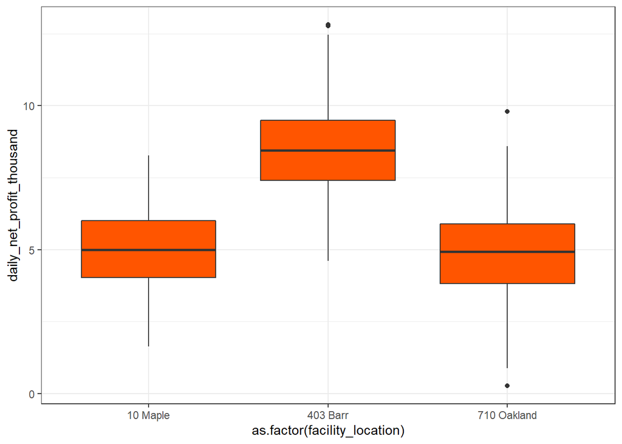

```r
ggplot(sec4Link, aes(as.factor(facility_location), daily_net_profit_thousand)) +
  geom_boxplot(fill = "#ff5500") +
  theme_bw()
```

From the plot, we can make our decision. The biggest daily net profit is in 403 Barr, probably it is in the city centre which lead to higher profit. However, the daily net profit in 10 Maple and 710 Oakland are almost the same, maybe they are in close location, or they are in the suburb. So, we need to focus on these two stores, try to make some plans to improve their net profit.

# ● Section 5 - Corrplot, Logistic Regression Model and interaction

## Instructions

Using the following data, determine what variables influence a franchise’s ultimate outcome – failure or success. Using any variables available to you, select the appropriate method and test your model. Discuss your results and describe your rationale for any data processing that you might undertake.

## Solution

```r
sec5Link <- read.csv("https://www.nd.edu/~sberry5/data/outcomeData.csv")
summary(sec5Link)
```

```
##     storeID      outcomeClosedOpen employeeCount
##  Min.   :  1.0   Min.   :0.0000    Min.   : 3.623
##  1st Qu.:119.5   1st Qu.:0.0000    1st Qu.: 9.502
##  Median :238.0   Median :0.0000    Median :12.347
##  Mean   :238.0   Mean   :0.4758    Mean   :12.325
##  3rd Qu.:356.5   3rd Qu.:1.0000    3rd Qu.:15.028
##  Max.   :475.0   Max.   :1.0000    Max.   :22.114
##  dailyNetProfitThousands quartersWithHealthViolations peoplePerSqMile
##  Min.   : 2.495          Min.   :0.0000               Min.   : 63.91
##  1st Qu.: 3.967          1st Qu.:0.0000               1st Qu.:195.15
##  Median : 4.650          Median :0.0000               Median :240.73
##  Mean   : 6.348          Mean   :0.5874               Mean   :244.51
##  3rd Qu.: 8.944          3rd Qu.:1.0000               3rd Qu.:295.11
##  Max.   :10.298          Max.   :3.0000               Max.   :393.97
```

```r
library(tidyverse)
```

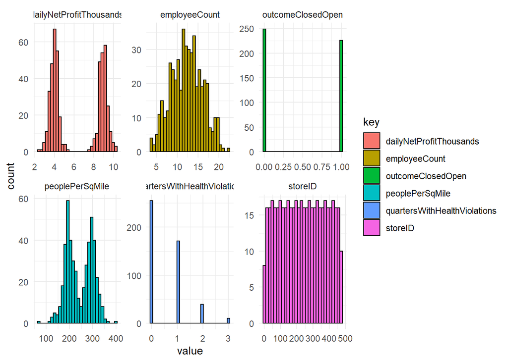

```r
sec5Link %>%
  keep(is.numeric) %>%
  gather() %>%
  ggplot() +
  geom_histogram(mapping = aes(x=value,fill=key), color="black") +
  facet_wrap(~ key, scales = "free") +
  theme_minimal()
```

```r
library(DT); library(broom)

carCor = cor(sec5Link[, 2:6])

knitr::kable(round(carCor, 2))
```

|  | outcomeClosedOpen | employeeCount | dailyNetProfitThousands | quartersWithHealthViolations | peoplePerSqMile |
| --- | --- | --- | --- | --- | --- |
| outcomeClosedOpen | 1.00 | 0.64 | 0.99 | -0.09 | 0.87 |
| employeeCount | 0.64 | 1.00 | 0.65 | -0.04 | 0.56 |
| dailyNetProfitThousands | 0.99 | 0.65 | 1.00 | -0.08 | 0.85 |
| quartersWithHealthViolations | -0.09 | -0.04 | -0.08 | 1.00 | -0.10 |
| peoplePerSqMile | 0.87 | 0.56 | 0.85 | -0.10 | 1.00 |

Corrplot

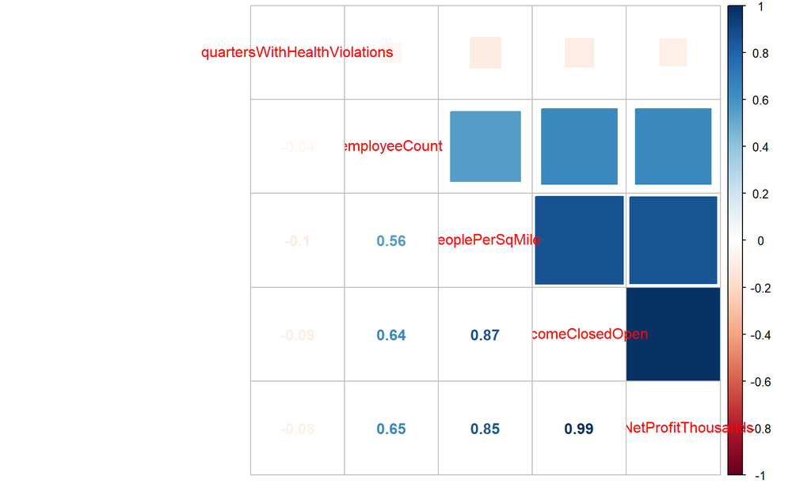

```r
corrplot::corrplot.mixed(carCor, lower = "number", upper = "square", order = "hclust")
```

From the corrplot, we can see the dailynetprofitThousands is the biggest variable influence the outcome close or open. Also, the employeecount and people per sqmile will effect the outcome. quartersWithHealthViolations has little effect with close or open.

Then, I want to use logistic regression model to test each variable.

```r
lmTest_employeeCount = glm(outcomeClosedOpen ~ employeeCount, data = sec5Link, family = binomial)

summary(lmTest_employeeCount)
```

```
##
## Call:
## glm(formula = outcomeClosedOpen ~ employeeCount, family = binomial,
##     data = sec5Link)
##
## Deviance Residuals:
##     Min       1Q   Median       3Q      Max
## -2.6579  -0.6888  -0.1829   0.6592   2.4547
##
## Coefficients:
##               Estimate Std. Error z value Pr(>|z|)
## (Intercept)   -7.19700    0.65703  -10.95   <2e-16 ***
## employeeCount  0.57008    0.05152   11.07   <2e-16 ***
## ---
## Signif. codes:  0 '***' 0.001 '**' 0.01 '*' 0.05 '.' 0.1 ' ' 1
##
## (Dispersion parameter for binomial family taken to be 1)
##
##     Null deviance: 657.38  on 474  degrees of freedom
## Residual deviance: 410.90  on 473  degrees of freedom
## AIC: 414.9
##
## Number of Fisher Scoring iterations: 5
```

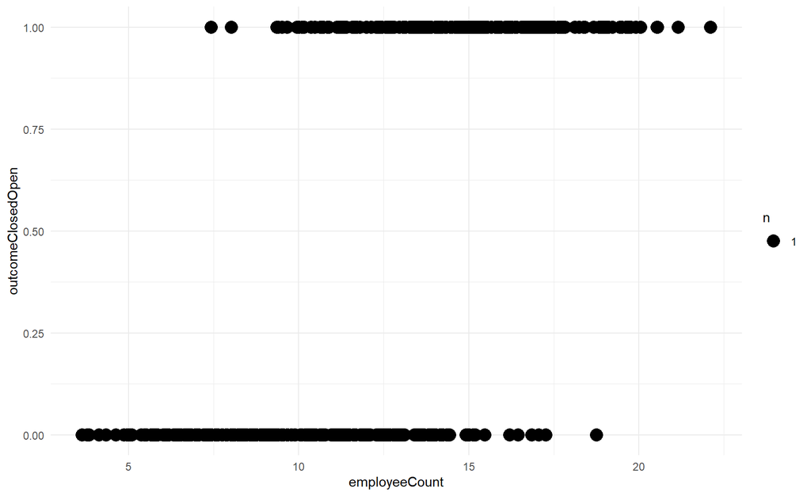

```r
ggplot(sec5Link) +
  geom_count(aes(employeeCount, outcomeClosedOpen)) +
  theme_minimal()
```

From the summary and plot, we can see employee count can fit the log regression of outcome

```r
lmTest_dailyNetProfitThousands = glm(outcomeClosedOpen ~ dailyNetProfitThousands, data = sec5Link, family = binomial)
summary(lmTest_dailyNetProfitThousands)
```

```
##
## Call:
## glm(formula = outcomeClosedOpen ~ dailyNetProfitThousands, family = binomial,
##     data = sec5Link)
##
## Deviance Residuals:
##        Min          1Q      Median          3Q         Max
## -7.570e-05  -2.100e-08  -2.100e-08   2.100e-08   7.399e-05
##
## Coefficients:
##                         Estimate Std. Error z value Pr(>|z|)
## (Intercept)              -128.20   52874.34  -0.002    0.998
## dailyNetProfitThousands    19.83    8106.05   0.002    0.998
##
## (Dispersion parameter for binomial family taken to be 1)
##
##     Null deviance: 6.5738e+02  on 474  degrees of freedom
## Residual deviance: 1.1294e-08  on 473  degrees of freedom
## AIC: 4
##
## Number of Fisher Scoring iterations: 25
```

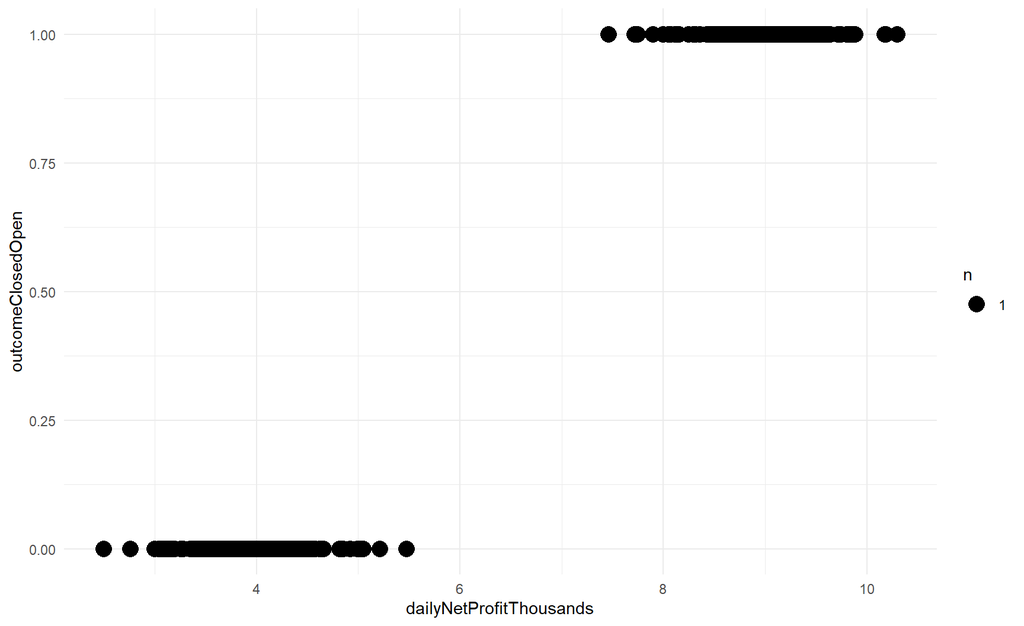

```r
ggplot(sec5Link) +
  geom_count(aes(dailyNetProfitThousands, outcomeClosedOpen)) +
  theme_minimal()
```

```r
lmTest_quartersWithHealthViolations  = glm(outcomeClosedOpen ~ quartersWithHealthViolations , data = sec5Link, family = binomial)

summary(lmTest_quartersWithHealthViolations )
```

```
##
## Call:
## glm(formula = outcomeClosedOpen ~ quartersWithHealthViolations,
##     family = binomial, data = sec5Link)
##
## Deviance Residuals:
##     Min       1Q   Median       3Q      Max
## -1.1989  -1.1989  -0.9908   1.1560   1.2647
##
## Coefficients:
##                              Estimate Std. Error z value Pr(>|z|)
## (Intercept)                   0.05052    0.11815   0.428   0.6689
## quartersWithHealthViolations -0.25341    0.12856  -1.971   0.0487 *
## ---
## Signif. codes:  0 '***' 0.001 '**' 0.01 '*' 0.05 '.' 0.1 ' ' 1
##
## (Dispersion parameter for binomial family taken to be 1)
##
##     Null deviance: 657.38  on 474  degrees of freedom
## Residual deviance: 653.41  on 473  degrees of freedom
## AIC: 657.41
##
## Number of Fisher Scoring iterations: 4
```

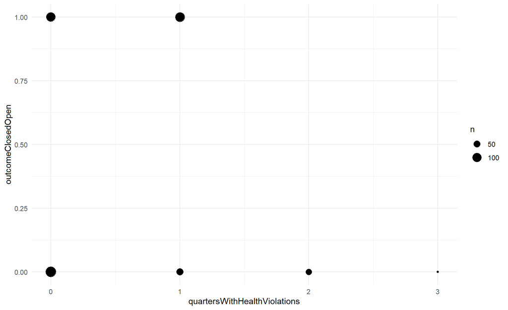

```r
ggplot(sec5Link) +
  geom_count(aes(quartersWithHealthViolations   , outcomeClosedOpen)) +
  theme_minimal()
```

```r
lmTest_peoplePerSqMile = glm(outcomeClosedOpen ~ peoplePerSqMile, data = sec5Link, family = binomial)

summary(lmTest_peoplePerSqMile)
```

```
##
## Call:
## glm(formula = outcomeClosedOpen ~ peoplePerSqMile, family = binomial,
##     data = sec5Link)
##
## Deviance Residuals:
##     Min       1Q   Median       3Q      Max
## -2.6515  -0.1268  -0.0115   0.1541   3.7754
##
## Coefficients:
##                   Estimate Std. Error z value Pr(>|z|)
## (Intercept)     -23.312824   2.398153  -9.721   <2e-16 ***
## peoplePerSqMile   0.093261   0.009487   9.830   <2e-16 ***
## ---
## Signif. codes:  0 '***' 0.001 '**' 0.01 '*' 0.05 '.' 0.1 ' ' 1
##
## (Dispersion parameter for binomial family taken to be 1)
##
##     Null deviance: 657.38  on 474  degrees of freedom
## Residual deviance: 125.34  on 473  degrees of freedom
## AIC: 129.34
##
## Number of Fisher Scoring iterations: 7
```

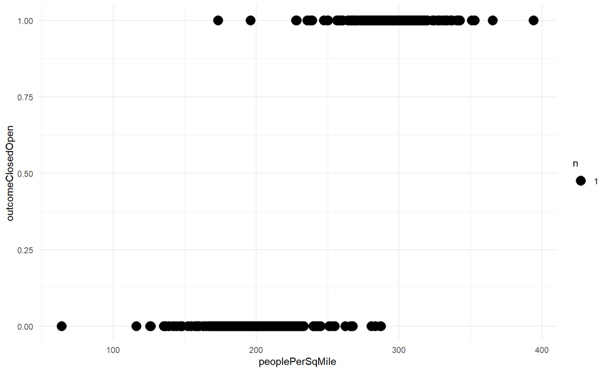

```r
ggplot(sec5Link) +
  geom_count(aes(peoplePerSqMile, outcomeClosedOpen)) +
  theme_minimal()
```

From the summary and plot, we can see peoplePerSqMile can fit the log regression of the outcome.

Then, We need to test their interaction.

```r
lmTest_peoplePerSqMile_employeeCount = glm(outcomeClosedOpen ~ peoplePerSqMile*employeeCount, data = sec5Link, family = binomial)
summary(lmTest_peoplePerSqMile_employeeCount)
```

```
##
## Call:
## glm(formula = outcomeClosedOpen ~ peoplePerSqMile * employeeCount,
##     family = binomial, data = sec5Link)
##
## Deviance Residuals:
##      Min        1Q    Median        3Q       Max
## -2.62429  -0.01116  -0.00008   0.03945   2.64193
##
## Coefficients:
##                                 Estimate Std. Error z value Pr(>|z|)
## (Intercept)                   -62.638840  18.099051  -3.461 0.000538 ***
## peoplePerSqMile                 0.197448   0.066502   2.969 0.002987 **
## employeeCount                   2.431314   1.168655   2.080 0.037485 *
## peoplePerSqMile:employeeCount  -0.005685   0.004487  -1.267 0.205160
## ---
## Signif. codes:  0 '***' 0.001 '**' 0.01 '*' 0.05 '.' 0.1 ' ' 1
##
## (Dispersion parameter for binomial family taken to be 1)
##
##     Null deviance: 657.376  on 474  degrees of freedom
## Residual deviance:  62.567  on 471  degrees of freedom
## AIC: 70.567
##
## Number of Fisher Scoring iterations: 9
```

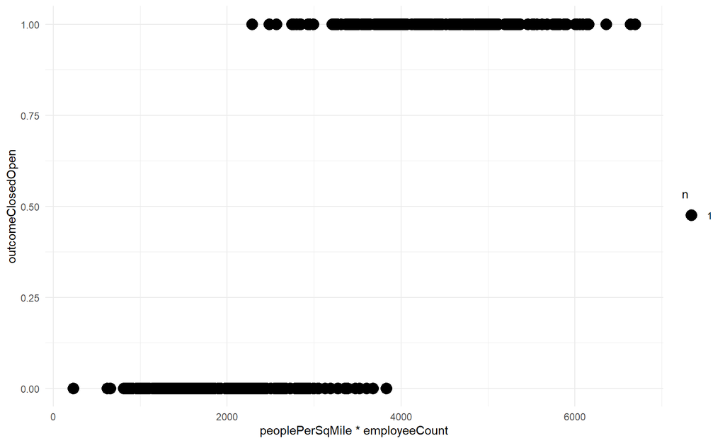

```r
ggplot(sec5Link) +
  geom_count(aes(peoplePerSqMile*employeeCount, outcomeClosedOpen)) +
  theme_minimal()
```

From the summary, we can see peoplePerSqMile:employeeCount are not significant, which means they don’t have interaction. So, we can make the conclusion that peoplepersqmile and employee count are both independent variable which will affect the outcome.

Decision: If I want to plan to open the store, I will focus on the area of the store (people per sq mile) and the number of employees, which will lead to the outcome.